# Project: No-Show Appointments Data Analysis

- Introduction
- Data Wrangling
- Exploratory Data Analysis
- Conclusions

## Introduction

> In this project we will be analyzing data associated with 100k medical appointments in Brazil.

> In particular, we will be interested in finding fascinating trends among the patients who show up for their appointments and how they differ from patients who did not show up for their appointments. In order to find trends, we will be analyzing the dataset in terms of various characteristics some of which include Sheduled day, Age, Gender, etc.,

> The trends among these characteristics will be found by answering the followwing questions throughout our analysis process :-
> 1. What factors are important for us to know in order to predict if a patient will show up for their scheduled appointment?
> 2. Whether age is associated with no_show?
> 3. Whether gender is associated with no_show?
> 4. Whether disease_count(hipertension, diabetes & alcoholism) is associated with no_show?
> 5. Whether handcap(no. of diasbilities) is associated with no_show?
> 6. Are sms_recieved and scholarship associated with no_show?
> 7. In which hospital/hospitals, most of the patients do not show up for their appointment?
> 8. On which day/days of the week, most of the patients did not show up for their appointment?

> *Let's begin with the analysis....*

**STEP 1 :-** Importing packages which will be used during the entire analysis process.

```python
# Import necessary packages including numpy, pandas, matplotlib and seaborn.
import numpy as np
import pandas as pd
import matplotlib.pyplot as plt
import seaborn as sns
% matplotlib inline
```

## Data Wrangling

> After importing packages, we will load in the data, check for cleanliness, and then trim and clean the dataset for analysis.

**STEP 2 :-** Loading data by reading the CSV file and printing the first few lines..

```python
# Load 'noshowappointments-kaggleV2-may-2016.csv'
df=pd.read_csv('noshowappointments-kaggleV2-may-2016.csv')
df.head()
```

|  | PatientId | AppointmentID | Gender | ScheduledDay | AppointmentDay | Age | Neighbourhood | Scholarship | Hipertension | Diabetes | Alcoholism | Handcap | SMS_received | No-show |
| --- | --- | --- | --- | --- | --- | --- | --- | --- | --- | --- | --- | --- | --- | --- |
| 0 | 2.987250e+13 | 5642903 | F | 2016-04-29T18:38:08Z | 2016-04-29T00:00:00Z | 62 | JARDIM DA PENHA | 0 | 1 | 0 | 0 | 0 | 0 | No |
| 1 | 5.589978e+14 | 5642503 | M | 2016-04-29T16:08:27Z | 2016-04-29T00:00:00Z | 56 | JARDIM DA PENHA | 0 | 0 | 0 | 0 | 0 | 0 | No |
| 2 | 4.262962e+12 | 5642549 | F | 2016-04-29T16:19:04Z | 2016-04-29T00:00:00Z | 62 | MATA DA PRAIA | 0 | 0 | 0 | 0 | 0 | 0 | No |
| 3 | 8.679512e+11 | 5642828 | F | 2016-04-29T17:29:31Z | 2016-04-29T00:00:00Z | 8 | PONTAL DE CAMBURI | 0 | 0 | 0 | 0 | 0 | 0 | No |
| 4 | 8.841186e+12 | 5642494 | F | 2016-04-29T16:07:23Z | 2016-04-29T00:00:00Z | 56 | JARDIM DA PENHA | 0 | 1 | 1 | 0 | 0 | 0 | No |

### Data Cleaning

**STEP 3 :-** Finding out the dimensions of the dataframe i.e., the total number of rows and columns

```python
# Get the number of rows and columns of the dataframe
df.shape
```

```
(110527, 14)
```

**STEP 4:-** Finding some useful descriptive statistics such as min,max,mean etc., for all the columns of the dataframe.

```python
# View the min, 25%, 50%, 75%, max pH values with Pandas describe
df.describe()
```

|  | PatientId | AppointmentID | Age | Scholarship | Hipertension | Diabetes | Alcoholism | Handcap | SMS_received |
| --- | --- | --- | --- | --- | --- | --- | --- | --- | --- |
| count | 1.105270e+05 | 1.105270e+05 | 110527.000000 | 110527.000000 | 110527.000000 | 110527.000000 | 110527.000000 | 110527.000000 | 110527.000000 |
| mean | 1.474963e+14 | 5.675305e+06 | 37.088874 | 0.098266 | 0.197246 | 0.071865 | 0.030400 | 0.022248 | 0.321026 |
| std | 2.560949e+14 | 7.129575e+04 | 23.110205 | 0.297675 | 0.397921 | 0.258265 | 0.171686 | 0.161543 | 0.466873 |
| min | 3.921784e+04 | 5.030230e+06 | -1.000000 | 0.000000 | 0.000000 | 0.000000 | 0.000000 | 0.000000 | 0.000000 |
| 25% | 4.172614e+12 | 5.640286e+06 | 18.000000 | 0.000000 | 0.000000 | 0.000000 | 0.000000 | 0.000000 | 0.000000 |
| 50% | 3.173184e+13 | 5.680573e+06 | 37.000000 | 0.000000 | 0.000000 | 0.000000 | 0.000000 | 0.000000 | 0.000000 |
| 75% | 9.439172e+13 | 5.725524e+06 | 55.000000 | 0.000000 | 0.000000 | 0.000000 | 0.000000 | 0.000000 | 1.000000 |
| max | 9.999816e+14 | 5.790484e+06 | 115.000000 | 1.000000 | 1.000000 | 1.000000 | 1.000000 | 4.000000 | 1.000000 |

As we can see, the minimum age is -1 and maximum age is 115. This means there are some outliers in our data(age). Let's confirm this by plotting a *boxplot*.If there is an outlier, it will be plotted as point in boxplot but other population will be grouped together and displayed as boxes.

**STEP 5 :-** Plotting boxplot to detect outliers in column Age

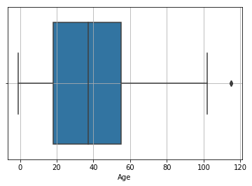

```python
# Detecting outliers
sns.boxplot(x=df['Age'])
plt.grid()
```

Above plot shows a point betwween 100-120 , it is an outlier since it is not included in the box i.e., nowhere near the quantiles. Also there are values less than 0 which is technically not feasible i.e., age cannot be less than or equal to 0.

*Removal of outliers is necessary* in this case since mostly all the observations lies near quantiles(18 to 55) and few different observations will affect the entire analysis based on age factor.

```python
# Filtering values between 0 and 100
df_filter=df.loc[(df['Age'] > 0) & (df['Age'] <= 100)]
```

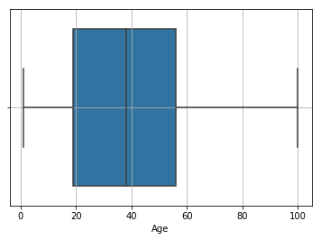

```python
# Plotting boxplot to check whether 100<=outliers<0 have been removed or not
sns.boxplot(x=df_filter['Age'])
plt.grid()
```

As we can see, the outliers less than 0 and outliers above 100 have been removed.

```python
# Checking the number of rows and columns in the dataframe
df_filter.shape
```

```
(106980, 14)
```

It can be observed that 3547 rows (110527-106980=3547) have been removed as outliers.

```python
# Assigning df_filter to df for simlicity and ease during further analysis process.
df=df_filter
```

**STEP 6 :-** After finding the dimensions, statistics and outliers, next we will take a look at the concise summary of the dataframe including the number of non-null values for each column..

```python
# Get the non-null values and datatypes of each column
df.info()
```

```
<class 'pandas.core.frame.DataFrame'>
Int64Index: 106980 entries, 0 to 110526
Data columns (total 14 columns):
PatientId         106980 non-null float64
AppointmentID     106980 non-null int64
Gender            106980 non-null object
ScheduledDay      106980 non-null object
AppointmentDay    106980 non-null object
Age               106980 non-null int64
Neighbourhood     106980 non-null object
Scholarship       106980 non-null int64
Hipertension      106980 non-null int64
Diabetes          106980 non-null int64
Alcoholism        106980 non-null int64
Handcap           106980 non-null int64
SMS_received      106980 non-null int64
No-show           106980 non-null object
dtypes: float64(1), int64(8), object(5)
memory usage: 12.2+ MB
```

**STEP 7:-** In the dataset, there are few columns that are not required during our analysis process. Let's drop these unnecessary columns..

```python
# Drop unnecessary columns
df.drop(['PatientId','AppointmentID'], axis=1, inplace=True)
```

```python
# Checking the summary again after dropping the columns
df.info()
```

```
<class 'pandas.core.frame.DataFrame'>
Int64Index: 106980 entries, 0 to 110526
Data columns (total 12 columns):
Gender            106980 non-null object
ScheduledDay      106980 non-null object
AppointmentDay    106980 non-null object
Age               106980 non-null int64
Neighbourhood     106980 non-null object
Scholarship       106980 non-null int64
Hipertension      106980 non-null int64
Diabetes          106980 non-null int64
Alcoholism        106980 non-null int64
Handcap           106980 non-null int64
SMS_received      106980 non-null int64
No-show           106980 non-null object
dtypes: int64(7), object(5)
memory usage: 10.6+ MB
```

**STEP 8 :-** For some easiness during the analysis, let's rename the columns by converting it into lower case..

```python
# Rename columns
df.rename(columns=lambda x: x.strip().lower(), inplace=True)
df.head(1)
```

|  | gender | scheduledday | appointmentday | age | neighbourhood | scholarship | hipertension | diabetes | alcoholism | handcap | sms_received | no-show |
| --- | --- | --- | --- | --- | --- | --- | --- | --- | --- | --- | --- | --- |
| 0 | F | 2016-04-29T18:38:08Z | 2016-04-29T00:00:00Z | 62 | JARDIM DA PENHA | 0 | 1 | 0 | 0 | 0 | 0 | No |

**STEP 9 :-** As we have seen above, both the days i.e., Scheduled day & Appointment day are in *object* format. For simplicity, converting them into *datetime* format..

```python
# Conversion of datatype : object to datetime
df['scheduledday']=pd.to_datetime(df['scheduledday'])
df['appointmentday']=pd.to_datetime(df['appointmentday'])
```

```python
# Checking the datatypes for each column of dataframe
df.dtypes
```

```
gender                    object
scheduledday      datetime64[ns]
appointmentday    datetime64[ns]
age                        int64
neighbourhood             object
scholarship                int64
hipertension               int64
diabetes                   int64
alcoholism                 int64
handcap                    int64
sms_received               int64
no-show                   object
dtype: object
```

We can see that data type for both the days has been changed, alongwith the data types of the columns.

**STEP 10 :-** Adding a column named *day_of_week* representing the name of days of week for *appointmentday* column.

```python
# Extracting the name of day of week using dt.day_name() method.
df['day_of_week']=df['appointmentday'].dt.day_name()
df.head()
```

|  | gender | scheduledday | appointmentday | age | neighbourhood | scholarship | hipertension | diabetes | alcoholism | handcap | sms_received | no-show | day_of_week |
| --- | --- | --- | --- | --- | --- | --- | --- | --- | --- | --- | --- | --- | --- |
| 0 | F | 2016-04-29 18:38:08 | 2016-04-29 | 62 | JARDIM DA PENHA | 0 | 1 | 0 | 0 | 0 | 0 | No | Friday |
| 1 | M | 2016-04-29 16:08:27 | 2016-04-29 | 56 | JARDIM DA PENHA | 0 | 0 | 0 | 0 | 0 | 0 | No | Friday |
| 2 | F | 2016-04-29 16:19:04 | 2016-04-29 | 62 | MATA DA PRAIA | 0 | 0 | 0 | 0 | 0 | 0 | No | Friday |
| 3 | F | 2016-04-29 17:29:31 | 2016-04-29 | 8 | PONTAL DE CAMBURI | 0 | 0 | 0 | 0 | 0 | 0 | No | Friday |
| 4 | F | 2016-04-29 16:07:23 | 2016-04-29 | 56 | JARDIM DA PENHA | 0 | 1 | 1 | 0 | 0 | 0 | No | Friday |

**STEP 11 -** For simplicity in further analysis, let's replace the values *Yes/No* of no-show column with values *1/0*.

```python
# Replace Yes/No with 1/0 and convert into type int.
df['no-show']=df['no-show'].replace(('Yes','No'),(1,0),regex=True).astype('int64')
df.head(7)
```

|  | gender | scheduledday | appointmentday | age | neighbourhood | scholarship | hipertension | diabetes | alcoholism | handcap | sms_received | no-show | day_of_week |
| --- | --- | --- | --- | --- | --- | --- | --- | --- | --- | --- | --- | --- | --- |
| 0 | F | 2016-04-29 18:38:08 | 2016-04-29 | 62 | JARDIM DA PENHA | 0 | 1 | 0 | 0 | 0 | 0 | 0 | Friday |
| 1 | M | 2016-04-29 16:08:27 | 2016-04-29 | 56 | JARDIM DA PENHA | 0 | 0 | 0 | 0 | 0 | 0 | 0 | Friday |
| 2 | F | 2016-04-29 16:19:04 | 2016-04-29 | 62 | MATA DA PRAIA | 0 | 0 | 0 | 0 | 0 | 0 | 0 | Friday |
| 3 | F | 2016-04-29 17:29:31 | 2016-04-29 | 8 | PONTAL DE CAMBURI | 0 | 0 | 0 | 0 | 0 | 0 | 0 | Friday |
| 4 | F | 2016-04-29 16:07:23 | 2016-04-29 | 56 | JARDIM DA PENHA | 0 | 1 | 1 | 0 | 0 | 0 | 0 | Friday |
| 5 | F | 2016-04-27 08:36:51 | 2016-04-29 | 76 | REPÚBLICA | 0 | 1 | 0 | 0 | 0 | 0 | 0 | Friday |
| 6 | F | 2016-04-27 15:05:12 | 2016-04-29 | 23 | GOIABEIRAS | 0 | 0 | 0 | 0 | 0 | 0 | 1 | Friday |

**STEP 12 :-** Checking the number of unique values in each column..

```python
# Unique values of each column
df.nunique()
```

```
gender                 2
scheduledday      100301
appointmentday        27
age                  100
neighbourhood         81
scholarship            2
hipertension           2
diabetes               2
alcoholism             2
handcap                5
sms_received           2
no-show                2
day_of_week            6
dtype: int64
```

Here the hipertension, diabetes and alcoholism have only two unique values i.e., 0 and 1. We can calculate an overall disease count by combining all the three using *numpy* and then we can check for the effect of disease count on patients who did not show up for their appointments.

**STEP 13.1 :-** Converting all three columns into Numpy array and then calculating their sum in order to get disease_count.

```python
# Creating disease_count array for dataframe
df_a=np.array(df.iloc[:,6:9])
df_a
```

```
array([[1, 0, 0],
       [0, 0, 0],
       [0, 0, 0],
       ...,
       [0, 0, 0],
       [0, 0, 0],
       [0, 0, 0]], dtype=int64)
```

```python
# Sum
df['disease_count']=df_a.sum(1)
df.head()
```

|  | gender | scheduledday | appointmentday | age | neighbourhood | scholarship | hipertension | diabetes | alcoholism | handcap | sms_received | no-show | day_of_week | disease_count |
| --- | --- | --- | --- | --- | --- | --- | --- | --- | --- | --- | --- | --- | --- | --- |
| 0 | F | 2016-04-29 18:38:08 | 2016-04-29 | 62 | JARDIM DA PENHA | 0 | 1 | 0 | 0 | 0 | 0 | 0 | Friday | 1 |
| 1 | M | 2016-04-29 16:08:27 | 2016-04-29 | 56 | JARDIM DA PENHA | 0 | 0 | 0 | 0 | 0 | 0 | 0 | Friday | 0 |
| 2 | F | 2016-04-29 16:19:04 | 2016-04-29 | 62 | MATA DA PRAIA | 0 | 0 | 0 | 0 | 0 | 0 | 0 | Friday | 0 |
| 3 | F | 2016-04-29 17:29:31 | 2016-04-29 | 8 | PONTAL DE CAMBURI | 0 | 0 | 0 | 0 | 0 | 0 | 0 | Friday | 0 |
| 4 | F | 2016-04-29 16:07:23 | 2016-04-29 | 56 | JARDIM DA PENHA | 0 | 1 | 1 | 0 | 0 | 0 | 0 | Friday | 2 |

As we can see, a new column has been added indicating whether the patient has all the three, any two or only one disease among the three diseases viz. hypertension,diabetes and alcoholism.

## Exploratory Data Analysis

> After trimming and cleaning the data,the next step is to explore in order to find trends by looking at relationships between variables. This can be done by performing computations and creating corresponding visualizations while answering the questions posed.

> Here,*no_show* is dependent variable and rest are independent variables.

*Let's begin our exploration!*

### What factors are important for us to know in order to predict if a patient will show up for their scheduled appointment?

**STEP 14 :-** Creating masks to filter out patients who showed up and not showed up for the appointment.

```python
# Creating masks
show=df['no-show']== False
not_show=df['no-show']== True
```

**STEP 15 :-** Constructing a histogram for all the columns in order to analyse what factors(features) are important to predict whether patient will show up for their scheduled appointment or not..

[output not shown]

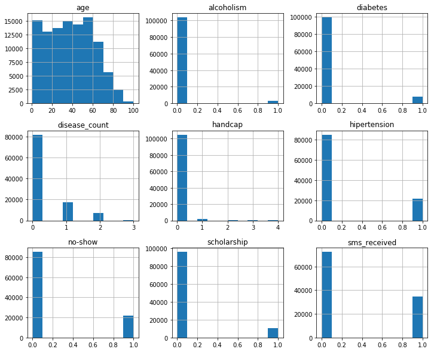

```python
# Plotting histogram for whole dataframe
df.hist(figsize=(12,10))
```

From the above histograms, we can see that columns *age*, *disease_count*, *handcap*, *scholarship*, *no-show* and *sms_recieved* can be analysed further in order to make the required prediction.

### Whether age is associated with no_show?

**STEP 16 :-** In order to check if age is associated with patients who did not show up for their appointment, let's construct a hisogram for both the masks created in the previous step i.e., *show* and *not_show*.

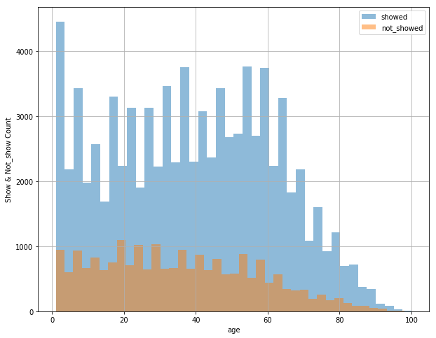

```python
# Plotting a histogram of age factor for both the masks with proper labels and legend
df.age[show].hist(alpha=0.5, bins=40, label='showed', figsize=(10,8))
df.age[not_show].hist(alpha=0.5, bins=40, label='not_showed', figsize=(10,8))
plt.xlabel('age')
plt.ylabel('Show & Not_show Count')
plt.legend();
```

> But only this factor cannot be used for our prediction since some of the patients of same age group range showed up for their appointment.

### Whether gender is associated with no_show?

**STEP 17 :-** To find out the association of gender with no-show, we can group the no_show patients with gender i.e., with *F and M* and calculate their mean.

```python
# Using groupby to get the mean no_show for both the genders
df.groupby('gender')['no-show'].mean()
```

```
gender
F    0.203563
M    0.200846
Name: no-show, dtype: float64
```

Let's analyse this using a *bar graph*..

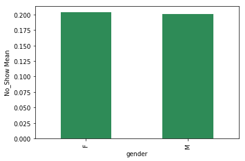

```python
df.groupby('gender')['no-show'].mean().plot(kind='bar',color='seagreen',)
plt.ylabel('No_Show Mean');
```

**STEP 18 :-** In order to check whether this analysis is useful for our prediction, let's see the total count of number of males and females.

```python
# Evaluating total count of each gender.
df.gender.value_counts()
```

```
F    70111
M    36869
Name: gender, dtype: int64
```

```python
# Using groupby to get the count of no_show for both the genders.
df.groupby('gender')['no-show'].value_counts()
```

```
gender  no-show
F       0          55839
        1          14272
M       0          29464
        1           7405
Name: no-show, dtype: int64
```

Here we can see that total number of females are much larger than total number of males. Hence, it is obvious that females who did not show up for the appointment will be more as compared to males.

> So, gender factor alone cannot be used for our prediction.

### Whether disease_count is associated with no_show?

Factor *disease_count* has been calculated by combing 3 factors, i.e.,*hypertension, diabetes, alcoholism*. We can check an overall association of all the 3 factors with patients who did not show up for their appointment by using this disease_count factor(no. of diseases a person is suffering from)

**STEP 19 :-** Grouping the no-show patients by disease_count,calculating their mean and constructing a bar graph.

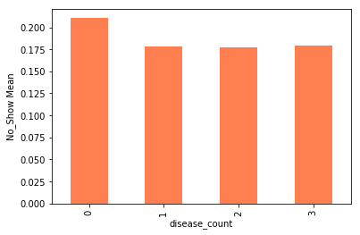

```python
# Using groupby to get the mean no_show for each disease_count
# Creating a bar chart wwith proper labels.
df.groupby('disease_count')['no-show'].mean().plot(kind='bar', color='coral')
plt.ylabel('No_Show Mean');
```

We cannot get any clear observation from the above graph. It is indicating that mostly patients with 0 disease_count do not show up for appointment.

> Let's expand our analysis by grouping no-show with both disease_count and gender, and see what happens.

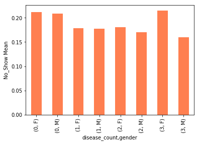

```python
# Using groupby to get the mean no_show for each disease_count and gender.
# Creating a bar chart wwith proper labels.
df.groupby(['disease_count','gender'])['no-show'].mean().plot(kind='bar', color='coral')
plt.ylabel('No_Show Mean');
```

Here, we can see that mostly females with disease_count 3 and 0, and males with disease_count 0, do not show up for their appointments. But, we cannot rely on this observation only for doing prediction.

> Let's explore the other factors as well.

### Whether handcap(no. of disabilities) is associated with no-show?

**STEP 20 :-** Grouping no-show patients with handcap,calculating their mean and representing via bar graph.

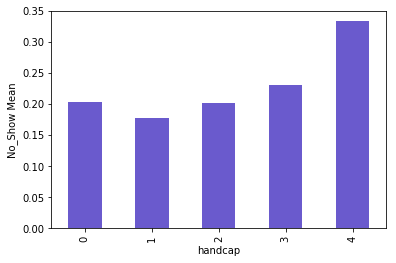

```python
# Using groupby to get the mean no_show for each handcap.
# Creating a bar chart wwith proper labels.
df.groupby('handcap')['no-show'].mean().plot(kind='bar', color='slateblue')
plt.ylabel('No_Show Mean');
```

It can be observed that patients with 4 disabilities are more likely to not show up for their appointments.

> Let's further dive deep into the analysis by combining handcap factor with other factors.

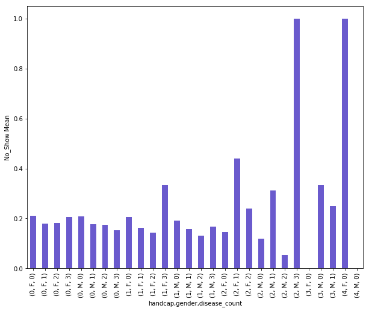

```python
# Using groupby to get the mean no_show for each handcap,gender and disease_count.
# Creating a bar chart wwith proper labels.
df.groupby(['handcap','gender','disease_count'])['no-show'].mean().plot(kind='bar',figsize=(10,8),color='slateblue')
plt.ylabel('No_Show Mean');
```

In the above graph, when we grouped no-show with handcap, gender and disease_count, it can be observed that females with handcap=4,disease_count=0 and males with handcap=2,disease_count=3 are more likely to not show up for their appointments.

### Are sms_recieved and scholarship associated with no-show?

**STEP 21 :-** Grouping no-show patients with sms_recieved,calculating their mean and representing via bar graph.

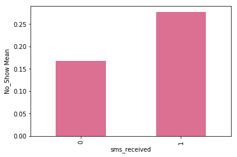

```python
# Using groupby to get the mean no_show for both the values of sms_recieved
# Creating a bar chart wwith proper labels.
df.groupby('sms_received')['no-show'].mean().plot(kind='bar',color='palevioletred')
plt.ylabel('No_Show Mean');
```

**STEP 22 :-** Grouping no-show patients with scholarship,calculating their mean and representing via bar graph.

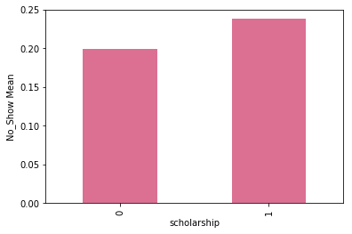

```python
# Using groupby to get the mean no_show for both the values of scholarship.
# Creating a bar chart wwith proper labels.
df.groupby('scholarship')['no-show'].mean().plot(kind='bar',color='palevioletred')
plt.ylabel('No_Show Mean');
```

> Let us enhance our analysis by combing this factor with other factors

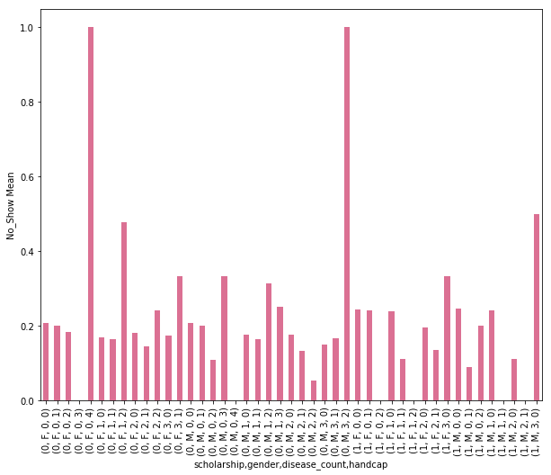

```python
# Using groupby to get the mean no_show for each scholarship,gender,disease_count and handcap.
# Creating a bar chart wwith proper labels.
df.groupby(['scholarship','gender','disease_count','handcap'])['no-show'].mean().plot(kind='bar',figsize=(10,8),color='palevioletred')
plt.ylabel('No_Show Mean');
```

Now this is quite interesting. Earlier we saw that patients with scholarship did not show up for their scheduled appointments. But from the above graph, it can be observed that mostly males with handcap=2, disease_count=3 and females with handcap=4, disease_count=0, both without scholarship; did not show up for their scheduled appointments.

### In which hospital/hospitals, most of the patients do not show up for their appointment?

**STEP 23 :-** Sort the hospitals in descending order by counting the number of patients who did not show for their scheduled appointments and representing it via bar graph.

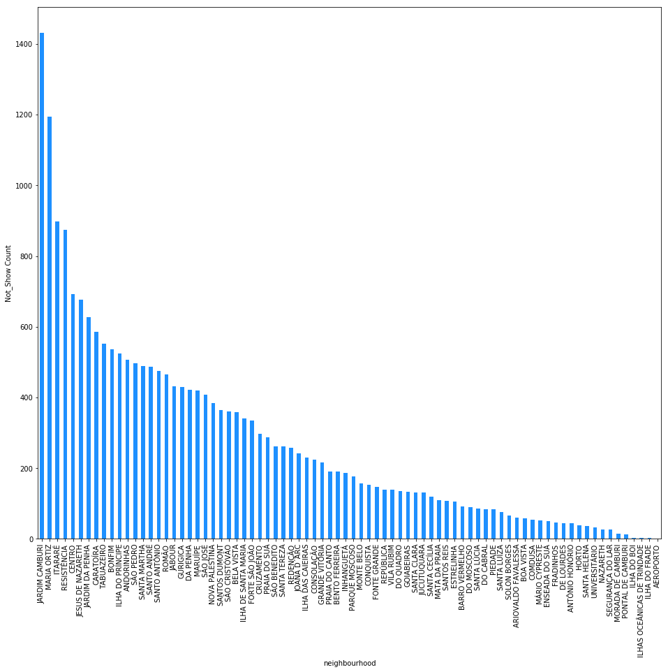

```python
# Calculating the total count of neighbourhood taking into account the n0t_show mask.
# Creating a bar chart with proper labels.
df.neighbourhood[not_show].value_counts(sort=True).plot(kind='bar', figsize=(16,14), color='dodgerblue')
plt.xlabel('neighbourhood')
plt.ylabel('Not_Show Count');
```

From the above graph we can see that JARDIM CAMBURI and MARIA ORTIZ are the two hospitals in which most of the people do not show up for their appointments.

> Further analysis can be done on hospitals individually considering all the important factors.

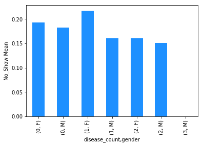

```python
# Using query to select the desired neighbourhood and groupby to get the mean no-show for each disease_count and gender for that neihbouhood
# Creating bar chart with proper labels
df.query('neighbourhood=="JARDIM CAMBURI"').groupby(['disease_count','gender'])['no-show'].mean().plot(kind='bar',color='dodgerblue')
plt.ylabel('No_Show Mean');
```

In the above graph, it can be observed that in JARDIM CAMBURI hospital, mostly the females with disease_count=1 do not show up for the scheduled appointments.

> Similarly a lot of observations can be performed on different hospitals.

### On which day/days of the week, most of the patients did not show up for their appointment?

**STEP 24 :-** In order to check on which days of the week patients did not show up for their appointment, let's construct a hisogram for both the masks created in the previous step i.e., *show* and *not_show*

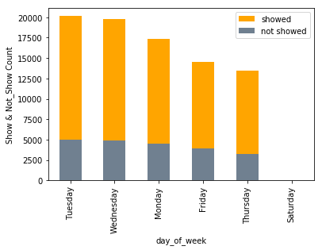

```python
# Creating a bar chart of day_of_week factor for both the masks with proper labels and legend.
df.day_of_week[show].value_counts().plot(kind='bar', label='showed', color='orange')
df.day_of_week[not_show].value_counts().plot(kind='bar', label='not showed', color='slategray')
plt.xlabel('day_of_week')
plt.ylabel('Show & Not_Show Count')
plt.legend();
```

## Limitations

There are various limitations in the exploration performed which include :-

- Further exploration could be done by calculating the no. of days between the scheduled day and appointment day,and further checking its effect on patients who did not show up for the appointment.
- With increase in no. of factors while grouping in order to visualize graphically, the results keep on varying to a large extent. It becomes difficult to draw any statistical conclusion. Some more precise method could be used while performing analysis.
- The graph representing hospitals in which patients did not show up for their appointment, sorted by value count will become bigger with increase in data.It could be represented by some other means in a more simpler manner.
- More accurate conclusions could be found by performing more observations.
- The conclusions could be verified by performing some statistical tests.